# TP_SRF_miTags_18S_and_16S_diversity_analysis

lrubinat

04/05/2016

# 1) 18S amplicons

## 1.1) Data overview

Let’s read the dataset and remove the samples containing less than 654 reads:

```
## [1] 3644   58
```

```
##     OTUId st019 st030 st044 st063
## 1  OTU_44    17     3    14    14
## 2  OTU_60     0     0     1     0
## 3 OTU_142     1     0     4     0
## 4 OTU_217     0     0     0     1
## 5 OTU_288     0     0     1     0
```

```
## [1] 3644   57
```

```
##         st019 st030 st044 st063 st076
## OTU_44     17     3    14    14    28
## OTU_60      0     0     1     0     4
## OTU_142     1     0     4     0    17
## OTU_217     0     0     0     1     9
## OTU_288     0     0     1     0     3
```

```
## [1] 3644    2
```

```
##                                                                                                                                         taxonomic_classification
## OTU_44  5396_AB199888|Eukaryota|Hacrobia|Haptophyta|Prymnesiophyceae|Prymnesiophyceae_X|Phaeocystales|Phaeocystales_X|Phaeocystaceae|Phaeocystis|Phaeocystis_sp.
## OTU_60                                                                    X77478.1.1803_Eukaryota;Haptophyta;Prymnesiophyceae;Phaeocystis;Phaeocystis_antarctica
## OTU_142                                  EF455763.1.1872_Eukaryota;SAR;Stramenopiles;Ochrophyta;Pelagophyceae;Pelagomonadales;Pelagomonas;Pelagomonas_calceolata
## OTU_217                                                                   GU825224.1.1204_Eukaryota;Haptophyta;Prymnesiophyceae;Phaeocystis;uncultured_eukaryote
## OTU_288                                                                      X77476.1.1803_Eukaryota;Haptophyta;Prymnesiophyceae;Phaeocystis;Phaeocystis_globosa
##                    class
## OTU_44  Prymnesiophyceae
## OTU_60  Prymnesiophyceae
## OTU_142    Pelagophyceae
## OTU_217 Prymnesiophyceae
## OTU_288 Prymnesiophyceae
```

```
## [1] 3644   55
```

```
##         st019 st030 st044 st063 st076
## OTU_44     17     3    14    14    28
## OTU_60      0     0     1     0     4
## OTU_142     1     0     4     0    17
## OTU_217     0     0     0     1     9
## OTU_288     0     0     1     0     3
```

```
##             st030             st101             st120 TARA_93_SUR_0d2.3
##               133               470               482                68
## TARA_94_SUR_0d2.3
##               439
```

```
## [1] 3644   50
```

## 1.2) Normalization

Let’s normalize the original dataset by randomly subsampling 654 reads in each station:

```r
library(vegan)
TP_18S_miTags_tax_occur_min654_t<-t(TP_18S_miTags_tax_occur_min654)
TP_18S_miTags_tax_occur_ss654<-rrarefy(TP_18S_miTags_tax_occur_min654_t, 654)
```

The normalized table shows the following dimensions and format:

```
## [1]   50 3644
```

```
##       OTU_44 OTU_60 OTU_142 OTU_217 OTU_288
## st019     11      0       0       0       0
## st044     10      1       4       0       1
## st063     14      0       0       1       0
## st076     25      1      11       7       2
## st083     13      1       0       2       1
```

Its content fits with the expected normalization values (654 reads per station):

```r
rowSums(TP_18S_miTags_tax_occur_ss654)
```

```
##              st019              st044              st063
##                654                654                654
##              st076              st083              st092
##                654                654                654
##              st141 TARA_100_SUR_0d2.3 TARA_102_SUR_0d2.3
##                654                654                654
## TARA_109_SUR_0d2.3 TARA_110_SUR_0d2.3 TARA_111_SUR_0d2.3
##                654                654                654
## TARA_112_SUR_0d2.3 TARA_122_SUR_0d2.3 TARA_123_SUR_0d2.3
##                654                654                654
## TARA_124_SUR_0d2.3 TARA_125_SUR_0d2.3 TARA_128_SUR_0d2.3
##                654                654                654
## TARA_132_SUR_0d2.3 TARA_133_SUR_0d2.3 TARA_137_SUR_0d2.3
##                654                654                654
## TARA_138_SUR_0d2.3 TARA_140_SUR_0d2.3 TARA_141_SUR_0d2.3
##                654                654                654
## TARA_142_SUR_0d2.3 TARA_145_SUR_0d2.3 TARA_146_SUR_0d2.3
##                654                654                654
## TARA_148_SUR_0d2.3 TARA_149_SUR_0d2.3 TARA_150_SUR_0d2.3
##                654                654                654
## TARA_151_SUR_0d2.3 TARA_152_SUR_0d2.3  TARA_56_SUR_0d2.3
##                654                654                654
##  TARA_57_SUR_0d2.3  TARA_62_SUR_0d2.3  TARA_64_SUR_0d2.3
##                654                654                654
##  TARA_65_SUR_0d2.3  TARA_66_SUR_0d2.3  TARA_67_SUR_0d2.3
##                654                654                654
##  TARA_68_SUR_0d2.3  TARA_70_SUR_0d2.3  TARA_72_SUR_0d2.3
##                654                654                654
##  TARA_76_SUR_0d2.3  TARA_78_SUR_0d2.3  TARA_82_SUR_0d2.3
##                654                654                654
##  TARA_84_SUR_0d2.3  TARA_85_SUR_0d2.3  TARA_96_SUR_0d2.3
##                654                654                654
##  TARA_98_SUR_0d2.3  TARA_99_SUR_0d2.3
##                654                654
```

Let’s check out how many OTUs don’t appear in the new table:

```r
length(which(colSums(TP_18S_miTags_tax_occur_ss654)==0))
```

```
## [1] 1157
```

```r
TP_18S_miTags_tax_occur_ss654_no_cero<-TP_18S_miTags_tax_occur_ss654[,-(which(colSums(TP_18S_miTags_tax_occur_ss654)==0))]
dim(TP_18S_miTags_tax_occur_ss654_no_cero)
```

```
## [1]   50 2487
```

## 1.3) Taxonomic composition analysis

Let’s add the taxonomic classification to the left OTUs by merging “TP_18S_miTags_tax_occur_ss654_no_cero” with “TP_18S_tax”:

```
## [1] 2487   53
```

```
##   Row.names st019 st044 st063 st076
## 1 OTU_10000     1     1     1     0
## 2 OTU_10001     0     0     0     0
## 3 OTU_10004     0     0     0     1
## 4 OTU_10005     0     0     0     0
## 5 OTU_10006     0     0     0     0
```

```
## [1] 2487   52
```

```
##           st019 st044 st063 st076 st083
## OTU_10000     1     1     1     0     0
## OTU_10001     0     0     0     0     0
## OTU_10004     0     0     0     1     0
## OTU_10005     0     0     0     0     0
## OTU_10006     0     0     0     0     0
```

```
## [1] 2487   53
```

```
##         st019 st044 st063 st076 st083
## OTU_44     11    10    14    25    13
## OTU_60      0     1     0     1     1
## OTU_142     0     4     0    11     0
## OTU_217     0     0     1     7     2
## OTU_288     0     1     0     2     1
```

```
## [1] 827  53
```

```
##          st019 st044 st063 st076 st083
## OTU_695      2     0     1     0     4
## OTU_1488     1     1     0     0     0
## OTU_1555     1     0     0     4     5
## OTU_1672     1     0     0     0     2
## OTU_1711     3     0     3     0     6
```

```
##          st019 st044 st063 st076 st083
## OTU_695      2     0     1     0     4
## OTU_1488     1     1     0     0     0
## OTU_1555     1     0     0     4     5
## OTU_1672     1     0     0     0     2
## OTU_1711     3     0     3     0     6
```

```
## [1] 325  50
```

```
## [1] 50
```

```
## [1] 43
```

```
## [1] 46
```

```
## [1] 50
```

```
## [1] 49
```

```
## [1] 47
```

```
## [1] 44
```

```
## [1] 32
```

```
## [1] 37
```

```
## [1] 0
```

```
## [1] 50
```

```
## [1] 20
```

```
## [1] 10
```

```
## [1] 0
```

```
## [1] 0
```

```
## [1] 0
```

```
## [1] 0
```

```
## [1] 0
```

```
## [1] 1
```

```
## [1] 3
```

```
## [1] 1
```

```
## [1] 0
```

```
## [1] 23
```

```
## [1] 20
```

```
## [1] 1
```

```
##                Group.1    x
## 16    Prymnesiophyceae 6376
## 8          Dinophyceae 2765
## 13       Pelagophyceae 2120
## 6      Cryptomonadales  689
## 15      Prasinophyceae  531
## 5        Chrysophyceae  467
## 7     Dictyochophyceae  458
## 10     Mamiellophyceae  260
## 1      Bacillariophyta  207
## 3   Chlorarachniophyta   92
## 2        Bolidophyceae   73
## 17          Rappemonad   35
## 12      Pavlovophyceae   32
## 9        Eustigmatales   11
## 4  Chlorodendrophyceae    3
## 11        Nephroselmis    1
## 14        Phaeophyceae    1
## 18       Xanthophyceae    1
```

```
##                Group.1   x
## 8          Dinophyceae 325
## 16    Prymnesiophyceae 124
## 1      Bacillariophyta  98
## 5        Chrysophyceae  77
## 6      Cryptomonadales  70
## 7     Dictyochophyceae  34
## 13       Pelagophyceae  21
## 3   Chlorarachniophyta  19
## 15      Prasinophyceae  17
## 2        Bolidophyceae  12
## 9        Eustigmatales   9
## 12      Pavlovophyceae   9
## 10     Mamiellophyceae   4
## 17          Rappemonad   3
## 4  Chlorodendrophyceae   2
## 11        Nephroselmis   1
## 14        Phaeophyceae   1
## 18       Xanthophyceae   1
```

```
##                     reads_per_class OTUs_per_class
## Bacillariophyta                 207             98
## Bolidophyceae                    73             12
## Chlorarachniophyta               92             19
## Chlorodendrophyceae               3              2
## Chrysophyceae                   467             77
## Cryptomonadales                 689             70
## Dictyochophyceae                458             34
## Dinophyceae                    2765            325
## Eustigmatales                    11              9
## Mamiellophyceae                 260              4
## Nephroselmis                      1              1
## Pavlovophyceae                   32              9
## Pelagophyceae                  2120             21
## Phaeophyceae                      1              1
## Prasinophyceae                  531             17
## Prymnesiophyceae               6376            124
## Rappemonad                       35              3
## Xanthophyceae                     1              1
```

```
##                     reads_per_class OTUs_per_class samples_per_class
## Prymnesiophyceae               6376            124                50
## Dinophyceae                    2765            325                50
## Pelagophyceae                  2120             21                50
## Cryptomonadales                 689             70                47
## Prasinophyceae                  531             17                43
## Chrysophyceae                   467             77                46
## Dictyochophyceae                458             34                49
## Mamiellophyceae                 260              4                20
## Bacillariophyta                 207             98                44
## Chlorarachniophyta               92             19                32
## Bolidophyceae                    73             12                37
## Rappemonad                       35              3                20
## Pavlovophyceae                   32              9                23
## Eustigmatales                    11              9                10
## Chlorodendrophyceae               3              2                 3
## Nephroselmis                      1              1                 1
## Phaeophyceae                      1              1                 1
## Xanthophyceae                     1              1                 1
```

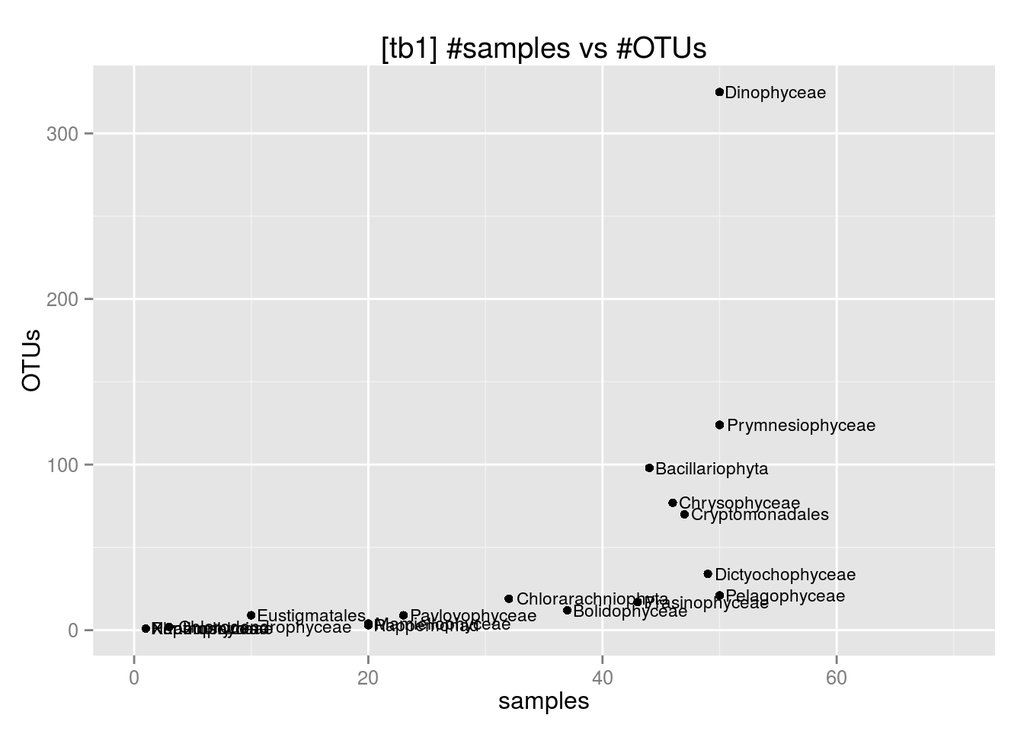

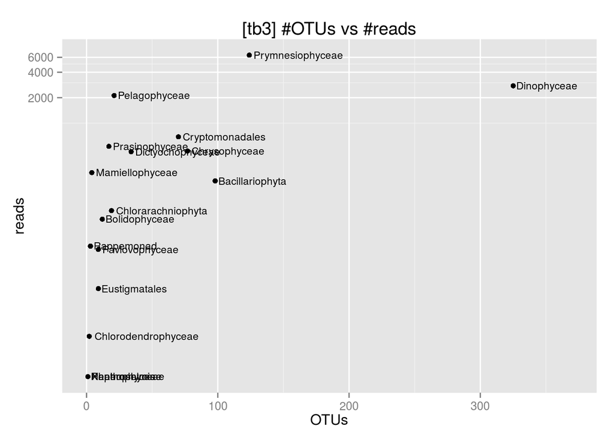

# 2) 16S amplicons

## 2.1) Data overview

```
## [1] 18633    59
```

```
##   OTUId st019 st030 st044 st063
## 1 OTU_1  1510   436   344   504
## 2 OTU_2   268   370   312   182
## 3 OTU_3   952   232   529   349
## 4 OTU_4   717   132   341   244
## 5 OTU_5   285   360    37    89
```

```
## [1] 18633    58
```

```
##       st019 st030 st044 st063 st076
## OTU_1  1510   436   344   504    88
## OTU_2   268   370   312   182   332
## OTU_3   952   232   529   349   168
## OTU_4   717   132   341   244   104
## OTU_5   285   360    37    89    47
```

```
## [1] 18633     3
```

```
##                                                                                                     taxonomic_classification
## OTU_1          GU940899.1.1230_Bacteria;Cyanobacteria;Cyanobacteria;SubsectionI;FamilyI;Prochlorococcus;uncultured_bacterium
## OTU_2 KC002198.1.1314_Bacteria;Proteobacteria;Alphaproteobacteria;SAR11_clade;Surface_1;unidentified_marine_bacterioplankton
## OTU_3          EU802538.1.1286_Bacteria;Proteobacteria;Deltaproteobacteria;SAR324_clade(Marine_group_B);uncultured_bacterium
## OTU_4          EU802790.1.1266_Bacteria;Cyanobacteria;Cyanobacteria;SubsectionI;FamilyI;Prochlorococcus;uncultured_bacterium
## OTU_5                 EU802283.1.1251_Bacteria;Proteobacteria;Alphaproteobacteria;SAR11_clade;Surface_1;uncultured_bacterium
##                      class_A                class_B
## OTU_1          cyanobacteria        Prochlorococcus
## OTU_2 heterotrophic_bacteria heterotrophic_bacteria
## OTU_3 heterotrophic_bacteria heterotrophic_bacteria
## OTU_4          cyanobacteria        Prochlorococcus
## OTU_5 heterotrophic_bacteria heterotrophic_bacteria
```

```
## [1] 18633    55
```

```
##       st019 st030 st044 st063 st076
## OTU_1  1510   436   344   504    88
## OTU_2   268   370   312   182   332
## OTU_3   952   232   529   349   168
## OTU_4   717   132   341   244   104
## OTU_5   285   360    37    89    47
```

```
## st101 st120
## 13676 17781
```

```
## [1] 18633    50
```

```
##       st019 st044 st063 st076 st083
## OTU_1  1510   344   504    88  1783
## OTU_2   268   312   182   332   311
## OTU_3   952   529   349   168  1105
## OTU_4   717   341   244   104   922
## OTU_5   285    37    89    47   203
```

## 2.2) Normalization

Let’s normalize the original dataset by randomly subsampling 13676 reads in each station:

```r
TP_16S_miTags_tax_occur_min13676_t<-t(TP_16S_miTags_tax_occur_min13676)
TP_16S_miTags_tax_occur_ss13676<-rrarefy(TP_16S_miTags_tax_occur_min13676_t, 13676)
```

The normalized table shows the following dimensions and format:

```
## [1]    50 18633
```

```
##       OTU_1 OTU_2 OTU_3 OTU_4 OTU_5
## st019   551    86   326   263    99
## st044   125   121   214   123    12
## st063   319   110   231   158    52
## st076    45   176    91    54    18
## st083   663   107   431   364    88
```

Its content fits with the expected normalization values (13676 reads per station):

```r
rowSums(TP_16S_miTags_tax_occur_ss13676)
```

```
##              st019              st044              st063
##              13676              13676              13676
##              st076              st083              st092
##              13676              13676              13676
##              st141 TARA_100_SUR_0d2.3 TARA_102_SUR_0d2.3
##              13676              13676              13676
## TARA_109_SUR_0d2.3 TARA_110_SUR_0d2.3 TARA_111_SUR_0d2.3
##              13676              13676              13676
## TARA_112_SUR_0d2.3 TARA_122_SUR_0d2.3 TARA_123_SUR_0d2.3
##              13676              13676              13676
## TARA_124_SUR_0d2.3 TARA_125_SUR_0d2.3 TARA_128_SUR_0d2.3
##              13676              13676              13676
## TARA_132_SUR_0d2.3 TARA_133_SUR_0d2.3 TARA_137_SUR_0d2.3
##              13676              13676              13676
## TARA_138_SUR_0d2.3 TARA_140_SUR_0d2.3 TARA_141_SUR_0d2.3
##              13676              13676              13676
## TARA_142_SUR_0d2.3 TARA_145_SUR_0d2.3 TARA_146_SUR_0d2.3
##              13676              13676              13676
## TARA_148_SUR_0d2.3 TARA_149_SUR_0d2.3 TARA_150_SUR_0d2.3
##              13676              13676              13676
## TARA_151_SUR_0d2.3 TARA_152_SUR_0d2.3  TARA_56_SUR_0d2.3
##              13676              13676              13676
##  TARA_57_SUR_0d2.3  TARA_62_SUR_0d2.3  TARA_64_SUR_0d2.3
##              13676              13676              13676
##  TARA_65_SUR_0d2.3  TARA_66_SUR_0d2.3  TARA_67_SUR_0d2.3
##              13676              13676              13676
##  TARA_68_SUR_0d2.3  TARA_70_SUR_0d2.3  TARA_72_SUR_0d2.3
##              13676              13676              13676
##  TARA_76_SUR_0d2.3  TARA_78_SUR_0d2.3  TARA_82_SUR_0d2.3
##              13676              13676              13676
##  TARA_84_SUR_0d2.3  TARA_85_SUR_0d2.3  TARA_96_SUR_0d2.3
##              13676              13676              13676
##  TARA_98_SUR_0d2.3  TARA_99_SUR_0d2.3
##              13676              13676
```

Let’s check out how many OTUs don’t appear in the new table:

```r
length(which(colSums(TP_16S_miTags_tax_occur_ss13676)==0))
```

```
## [1] 7022
```

```r
TP_16S_miTags_tax_occur_ss13676_no_cero<-TP_16S_miTags_tax_occur_ss13676[,-(which(colSums(TP_16S_miTags_tax_occur_ss13676)==0))]
dim(TP_16S_miTags_tax_occur_ss13676_no_cero)
```

```
## [1]    50 11611
```

## 2.3) Taxonomic composition analysis

Let’s add the taxonomic classification to the left OTUs by merging “TP_16S_miTags_tax_occur_ss13676_no_cero” with “TP_16S_miTags_tax”.

```
## [1] 11611    54
```

```
##   Row.names st019 st044 st063 st076
## 1     OTU_1   551   125   319    45
## 2    OTU_10    54    70    69    91
## 3   OTU_100    26     9    23     8
## 4  OTU_1000    10     0     0     0
## 5 OTU_10002     0     0     0     0
```

```
## [1] 11611    53
```

```
##           st019 st044 st063 st076 st083
## OTU_1       551   125   319    45   663
## OTU_10       54    70    69    91    38
## OTU_100      26     9    23     8    30
## OTU_1000     10     0     0     0     0
## OTU_10002     0     0     0     0     0
```

```
## [1] 11611    54
```

```
##                                                                                                     taxonomic_classification
## OTU_1          GU940899.1.1230_Bacteria;Cyanobacteria;Cyanobacteria;SubsectionI;FamilyI;Prochlorococcus;uncultured_bacterium
## OTU_2 KC002198.1.1314_Bacteria;Proteobacteria;Alphaproteobacteria;SAR11_clade;Surface_1;unidentified_marine_bacterioplankton
## OTU_3          EU802538.1.1286_Bacteria;Proteobacteria;Deltaproteobacteria;SAR324_clade(Marine_group_B);uncultured_bacterium
## OTU_4          EU802790.1.1266_Bacteria;Cyanobacteria;Cyanobacteria;SubsectionI;FamilyI;Prochlorococcus;uncultured_bacterium
## OTU_5                 EU802283.1.1251_Bacteria;Proteobacteria;Alphaproteobacteria;SAR11_clade;Surface_1;uncultured_bacterium
##                      class_A                class_B
## OTU_1          cyanobacteria        Prochlorococcus
## OTU_2 heterotrophic_bacteria heterotrophic_bacteria
## OTU_3 heterotrophic_bacteria heterotrophic_bacteria
## OTU_4          cyanobacteria        Prochlorococcus
## OTU_5 heterotrophic_bacteria heterotrophic_bacteria
```

```
## [1] 652  54
```

```
## [1] 10959    54
```

```
##         TARA_99_SUR_0d2.3
## OTU_52                  0
## OTU_59                  0
## OTU_63                  0
## OTU_127                 1
## OTU_152                 0
##                                                        taxonomic_classification
## OTU_52  HQ671891.1.1439_Bacteria;Cyanobacteria;Chloroplast;uncultured_bacterium
## OTU_59  JX537858.1.1224_Bacteria;Cyanobacteria;Chloroplast;uncultured_bacterium
## OTU_63  GU061828.1.1453_Bacteria;Cyanobacteria;Chloroplast;uncultured_bacterium
## OTU_127     AB199886.1.1219_Bacteria;Cyanobacteria;Chloroplast;Phalacroma_mitra
## OTU_152 HQ672194.1.1422_Bacteria;Cyanobacteria;Chloroplast;uncultured_bacterium
##                class_A        class_B
## OTU_52  other_plastids other_plastids
## OTU_59  other_plastids other_plastids
## OTU_63  other_plastids other_plastids
## OTU_127 other_plastids other_plastids
## OTU_152 other_plastids other_plastids
```

```
##       TARA_99_SUR_0d2.3
## OTU_1               402
## OTU_2               174
## OTU_3               274
## OTU_4               218
## OTU_5               108
##                                                                                                     taxonomic_classification
## OTU_1          GU940899.1.1230_Bacteria;Cyanobacteria;Cyanobacteria;SubsectionI;FamilyI;Prochlorococcus;uncultured_bacterium
## OTU_2 KC002198.1.1314_Bacteria;Proteobacteria;Alphaproteobacteria;SAR11_clade;Surface_1;unidentified_marine_bacterioplankton
## OTU_3          EU802538.1.1286_Bacteria;Proteobacteria;Deltaproteobacteria;SAR324_clade(Marine_group_B);uncultured_bacterium
## OTU_4          EU802790.1.1266_Bacteria;Cyanobacteria;Cyanobacteria;SubsectionI;FamilyI;Prochlorococcus;uncultured_bacterium
## OTU_5                 EU802283.1.1251_Bacteria;Proteobacteria;Alphaproteobacteria;SAR11_clade;Surface_1;uncultured_bacterium
##                      class_A                class_B
## OTU_1          cyanobacteria        Prochlorococcus
## OTU_2 heterotrophic_bacteria heterotrophic_bacteria
## OTU_3 heterotrophic_bacteria heterotrophic_bacteria
## OTU_4          cyanobacteria        Prochlorococcus
## OTU_5 heterotrophic_bacteria heterotrophic_bacteria
```

```r
TP_16S_miTags_class_summary_reads_per_class_protists<-aggregate(rowSums(TP_16S_miTags_protists[1:50]), list(TP_16S_miTags_protists$class_A), sum)
# count the different groups

TP_16S_miTags_class_summary_otus_per_class_protists<-aggregate(rowSums(TP_16S_miTags_protists[1:50]), list(TP_16S_miTags_protists$class_A), length)

## READS PER CLASS ##
attach(TP_16S_miTags_class_summary_reads_per_class_protists)
TP_16S_miTags_class_summary_reads_per_class_protists_order<-TP_16S_miTags_class_summary_reads_per_class_protists[order(-x),]
detach(TP_16S_miTags_class_summary_reads_per_class_protists)
TP_16S_miTags_class_summary_reads_per_class_protists_order
```

```
##            Group.1     x
## 5   other_plastids 35007
## 3  Mamiellophyceae  3086
## 6   Prasinophyceae   292
## 7 Trebouxiophyceae    42
## 1    Chlorophyceae     7
## 4     Nephroselmis     3
## 8      Ulvophyceae     3
## 2      Dinophyceae     2
```

```r
#fix column names
row.names(TP_16S_miTags_class_summary_reads_per_class_protists_order)<-TP_16S_miTags_class_summary_reads_per_class_protists_order[,1]
TP_16S_miTags_class_summary_reads_per_class_protists_order<-TP_16S_miTags_class_summary_reads_per_class_protists_order[c(-1)]
colnames(TP_16S_miTags_class_summary_reads_per_class_protists_order)<-c("reads_per_class")


## OTUs PER CLASS ##
attach(TP_16S_miTags_class_summary_otus_per_class_protists)
TP_16S_miTags_class_summary_otus_per_class_protists_order<-TP_16S_miTags_class_summary_otus_per_class_protists[order(-x),]
detach(TP_16S_miTags_class_summary_otus_per_class_protists)
TP_16S_miTags_class_summary_otus_per_class_protists_order
```

```
##            Group.1   x
## 5   other_plastids 528
## 3  Mamiellophyceae  57
## 6   Prasinophyceae  45
## 7 Trebouxiophyceae  10
## 1    Chlorophyceae   7
## 4     Nephroselmis   3
## 2      Dinophyceae   1
## 8      Ulvophyceae   1
```

```r
row.names(TP_16S_miTags_class_summary_otus_per_class_protists_order)<-TP_16S_miTags_class_summary_otus_per_class_protists_order[,1]
TP_16S_miTags_class_summary_otus_per_class_protists_order<-TP_16S_miTags_class_summary_otus_per_class_protists_order[c(-1)]
colnames(TP_16S_miTags_class_summary_otus_per_class_protists_order)<-c("OTUs_per_class")
```

```r
TP_16S_miTags_class_summary_reads_per_class_bacteria<-aggregate(rowSums(TP_16S_miTags_bacteria[1:50]), list(TP_16S_miTags_bacteria$class_A), sum)
# count the different groups

TP_16S_miTags_class_summary_otus_per_class_bacteria<-aggregate(rowSums(TP_16S_miTags_bacteria[1:50]), list(TP_16S_miTags_bacteria$class_A), length)

## READS PER CLASS ##
attach(TP_16S_miTags_class_summary_reads_per_class_bacteria)
TP_16S_miTags_class_summary_reads_per_class_bacteria_order<-TP_16S_miTags_class_summary_reads_per_class_bacteria[order(-x),]
detach(TP_16S_miTags_class_summary_reads_per_class_bacteria)
TP_16S_miTags_class_summary_reads_per_class_bacteria_order
```

```
##                  Group.1      x
## 2 heterotrophic_bacteria 561622
## 1          cyanobacteria  83736
```

```r
#fix column names
row.names(TP_16S_miTags_class_summary_reads_per_class_bacteria_order)<-TP_16S_miTags_class_summary_reads_per_class_bacteria_order[,1]
TP_16S_miTags_class_summary_reads_per_class_bacteria_order<-TP_16S_miTags_class_summary_reads_per_class_bacteria_order[c(-1)]
colnames(TP_16S_miTags_class_summary_reads_per_class_bacteria_order)<-c("reads_per_class")


## OTUs PER CLASS ##
attach(TP_16S_miTags_class_summary_otus_per_class_bacteria)
TP_16S_miTags_class_summary_otus_per_class_bacteria_order<-TP_16S_miTags_class_summary_otus_per_class_bacteria[order(-x),]
detach(TP_16S_miTags_class_summary_otus_per_class_bacteria)
TP_16S_miTags_class_summary_otus_per_class_bacteria_order
```

```
##                  Group.1     x
## 2 heterotrophic_bacteria 10507
## 1          cyanobacteria   452
```

```r
row.names(TP_16S_miTags_class_summary_otus_per_class_bacteria_order)<-TP_16S_miTags_class_summary_otus_per_class_bacteria_order[,1]
TP_16S_miTags_class_summary_otus_per_class_bacteria_order<-TP_16S_miTags_class_summary_otus_per_class_bacteria_order[c(-1)]
colnames(TP_16S_miTags_class_summary_otus_per_class_bacteria_order)<-c("OTUs_per_class")
```

```
## [1] 1
```

```
## [1] 44
```

```
## [1] 43
```

```
## [1] 7
```

```
## [1] 3
```

```
## [1] 20
```

```
## [1] 3
```

```
## [1] 50
```

```
## [1] 50
```

```
## [1] 50
```

```
##                 reads_per_class OTUs_per_class
## Chlorophyceae                 7              7
## Dinophyceae                   2              1
## Mamiellophyceae            3086             57
## Nephroselmis                  3              3
## other_plastids            35007            528
```

```
##                        reads_per_class OTUs_per_class
## cyanobacteria                    83736            452
## heterotrophic_bacteria          561622          10507
## NA                                  NA             NA
## NA.1                                NA             NA
## NA.2                                NA             NA
```

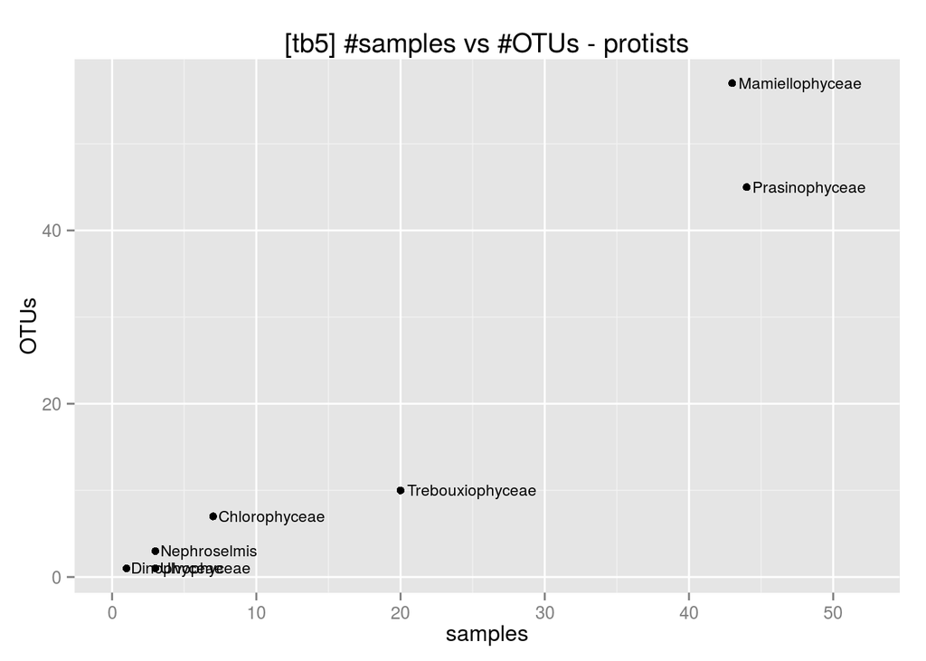

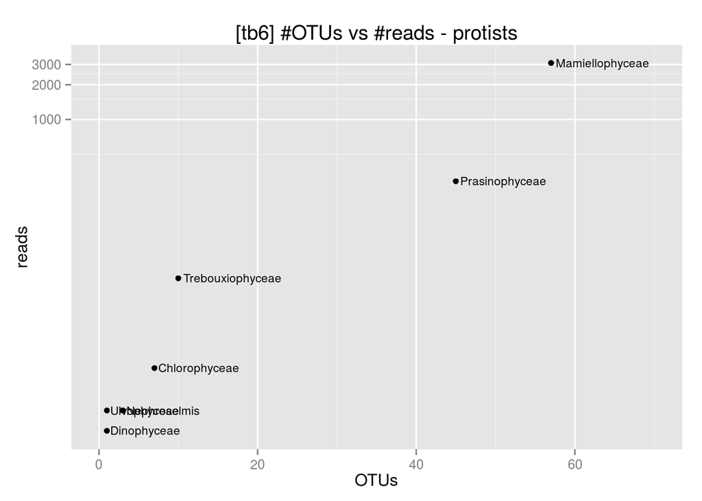

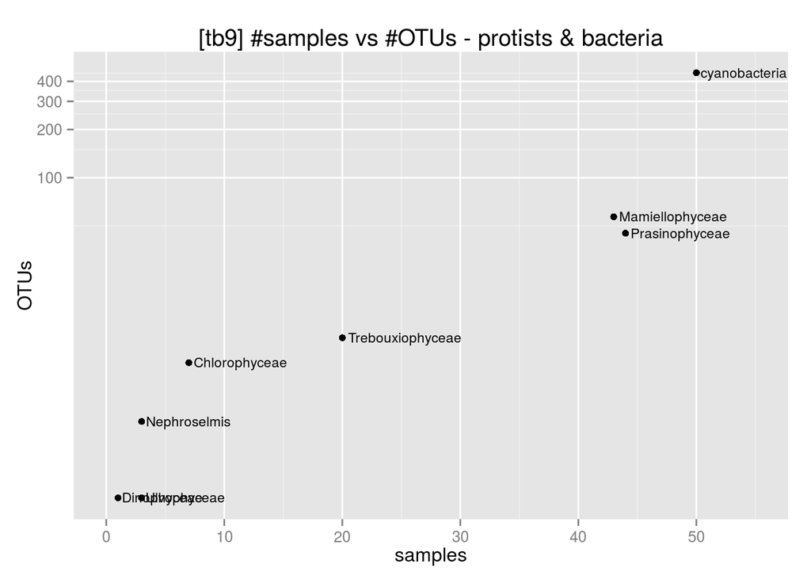

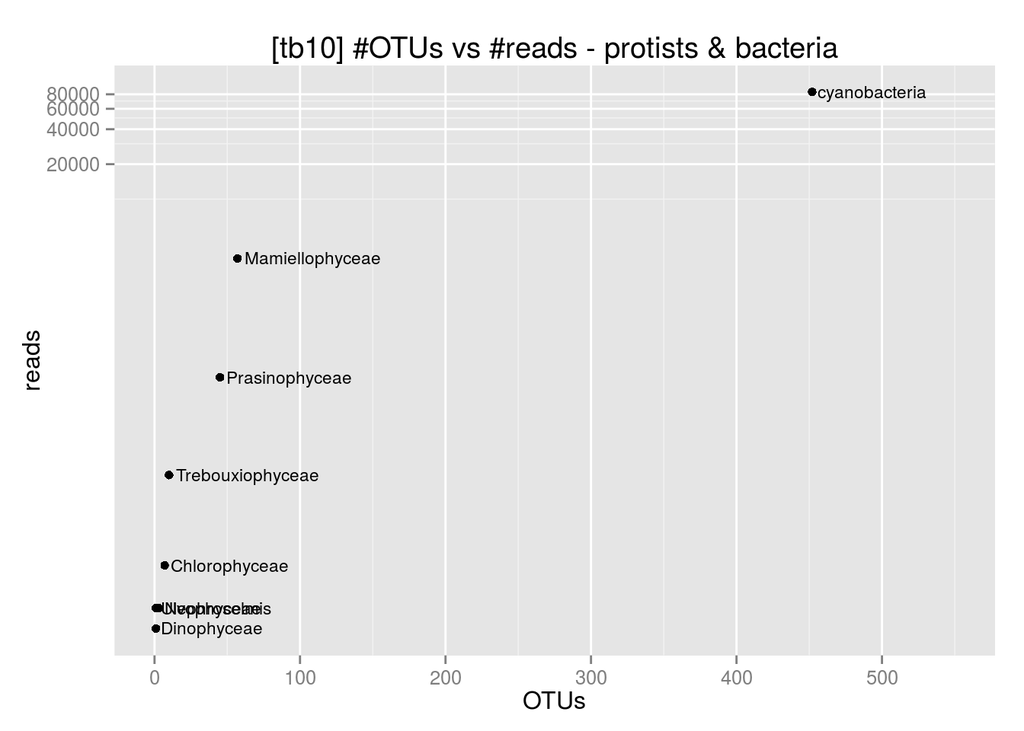